# Correlations (Clean code)

Eva Kim

2024-05-17

Taking the intersection of differentially abundant taxa and graphing them revealed that even when taking the intersection, lung tissue taxa prevalence was spurious. Since DAA was redone to reflect testing based on hypotheses, I am rerunning this code to see if there are differences. Lung tissue taxa prevalence is still spurious so I will be focusing on fecal taxa only.

# Method

One method of running correlations is using the transformed relative abundance data then using Pearson correlation. I had previously used arcsine transformation and considered the centered-log ratio (CLR) transformation. However, plotting correlations with raw relative abundance may show non-obvious relationships. Per Dr. Shi’s recommendation, I will be using Spearman’s rank correlation (non-parametric) with the raw relative abundance values instead.

There are certain **lung tissue** taxa of interest for Dr. Ingram: Flavobacteriales, *Capnocytophaga* and *Flavobacterium*. In addition, differential immune cell counting data has been added on 2/10/2024.

# Set-Up

## Load libraries and directories

```r
# rm(list = ls(all = TRUE)) ## Unload all packages if necessary
library(rstatix)
library(ggpubr)
library(ANCOMBC)
library(pals)
library(RColorBrewer)
library(ggrepel)
library(DT)
library(plotly)
library(parallel)
library(dplyr)
library(tidyr)
library(readr)
library(tibble)
library(stringr)
library(phyloseq)
library(Hmisc)
library(cowplot)
library(ggtext)
```

```r
rm(list=ls()) # clear environment

git.dir = file.path("~/GLP_KO_Microbiome")

fecal.file = file.path(git.dir, "Fecal_clean_metadata.csv")
meta_F.df = read_csv(fecal.file, show_col_types = FALSE)

F_intersect.file = file.path(git.dir, "F_Intersection_redo.csv")
F_intersect.df = read_csv(F_intersect.file, show_col_types = FALSE)

F_RA.file = file.path("F_rel_ab_full.csv")
F_RA.df = read_csv(F_RA.file, show_col_types = FALSE)

map.file = file.path(git.dir, "Metadata_with_all_blanks.csv")
meta.df = read_csv(map.file, show_col_types = FALSE)

glucose.file = file.path(git.dir, "glucose_calc.csv")
glucose.df = read_csv(glucose.file, show_col_types = FALSE)

ps.rds <- file.path(git.dir, "ps_g_notree_F_filter") # ps AFTER filtering by prevalence
ps <- read_rds(ps.rds)
ps
```

```
## phyloseq-class experiment-level object
## otu_table()   OTU Table:         [ 74 taxa and 176 samples ]
## sample_data() Sample Data:       [ 176 samples by 40 sample variables ]
## tax_table()   Taxonomy Table:    [ 74 taxa by 6 taxonomic ranks ]
```

```r
LT_RA.file = file.path("LT_rel_ab_full.csv")
LT_RA.df = read_csv(LT_RA.file, show_col_types = FALSE)

diff.file = file.path(git.dir, "microbiome_cell_diff_counts_bal.csv")
diff.df = read_csv(diff.file,col_names = TRUE, show_col_types = FALSE )

protein.file = file.path(git.dir, "Proteins_import.csv")
protein.df = read_csv(protein.file,col_names = TRUE, show_col_types = FALSE )

trichrome.file = file.path(git.dir, "Trichrome_import.csv")
trichrome.df = read_csv(trichrome.file,col_names = TRUE, show_col_types = FALSE )

hist.file = file.path(git.dir, "histology_GLP_mice_import.csv")
hist.df = read_csv(hist.file, show_col_types = FALSE)
```

# Correlations: Tests to run

Based on the graphs of differentially abundant taxa that were both identified by DESeq2 and ANCOM-II, many taxa were spurious. As such, I will only run taxon-health marker correlation with fecal taxa.

In addition, there are a lot of variables to choose from and I expect more information to be available in near future. For now, the variables that I am most interested are: 1. Weight 2. Glucose calculations: AUC, MaxPeak, baseline 3. Serum protein levels except for insulin 4. Immune cells (eosinophils and neutrophils) 5. Histology scores and trichrome data

For simplicity, only fecal microbiome relative abundance on the same day as the health data was collected will be used.

```r
meta_F.df %>% select(Label, Mouse, Genotype:Surgery, Week, Weight_g_wk0:Weight_g_wk14, Group) -> meta.slim

glucose.df %>% select(Mouse, Week, AUC:Glucose_min_0) -> glucose.slim

meta.slim %>%
  left_join(glucose.slim, by = c("Mouse", "Week")) -> corr.df

corr.df %>% filter(Week == 13) %>%
  right_join(diff.df, by = "Mouse") -> diff.meta.df
```

```r
meta_F.df %>% dim()
```

```
## [1] 176  22
```

```r
F_RA.df %>% distinct(Sample) %>% nrow()
```

```
## [1] 176
```

```r
F_RA.df %>% filter(taxon %in% F_intersect.df$taxon) %>%
  dplyr::rename(Label = Sample) %>%
  select(Label, taxon, RA) %>%
  pivot_wider(names_from = taxon,
              values_from = RA) -> FullRA.df

FullRA.df %>% head()
```

| Label | Candidatus Stoquefichus | Romboutsia | Streptococcus | Lactococcus | Parasutterella | Tuzzerella | Tyzzerella | Lachnospiraceae UCG-001 | Bifidobacterium | Acetatifactor | Coriobacteriaceae UCG-002 | Rikenella | Muribaculum | Rikenellaceae RC9 gut group | Prevotellaceae UCG-001 | Prevotellaceae NK3B31 group | Marvinbryantia | Atopobiaceae | Bifidobacteriaceae | Enterococcaceae | Erysipelatoclostridiaceae | Muribaculaceae | Peptostreptococcaceae | Prevotellaceae | Rikenellaceae | Streptococcaceae | Sutterellaceae | Bifidobacteriales | Burkholderiales | … |
| --- | --- | --- | --- | --- | --- | --- | --- | --- | --- | --- | --- | --- | --- | --- | --- | --- | --- | --- | --- | --- | --- | --- | --- | --- | --- | --- | --- | --- | --- | --- |
| 5 | 0.0006417112 | 0.0000000000 | 0.0000000000 | 0 | 0.026524064 | 0.0000000000 | 0.0094117647 | 0.017967914 | 0.16691622 | 0.0010695187 | 0.0423529412 | 0.003493761 | 0.02481283 | 0.0014260250 | 0.08777184 | 0.027522282 | 0.012762923 | 0.0423529412 | 0.16691622 | 0.000855615 | 0.0007843137 | 0.02481283 | 0.0000000000 | 0.11529412 | 0.016327986 | 0.0000000000 | 0.026524064 | 0.16691622 | 0.026524064 | … |
| 40 | 0.0000000000 | 0.0000000000 | 0.0000000000 | 0 | 0.036158950 | 0.0007455454 | 0.0149109073 | 0.004025945 | 0.16908969 | 0.0000000000 | 0.0876761351 | 0.002907627 | 0.01543279 | 0.0024602997 | 0.05039887 | 0.023335570 | 0.004995154 | 0.0876761351 | 0.16908969 | 0.001565645 | 0.0000000000 | 0.01543279 | 0.0000000000 | 0.07373444 | 0.024901215 | 0.0000000000 | 0.036158950 | 0.16908969 | 0.036158950 | … |
| 32 | 0.0007212405 | 0.0000000000 | 0.0000000000 | 0 | 0.032876548 | 0.0000000000 | 0.0099771607 | 0.001923308 | 0.22634932 | 0.0000000000 | 0.0780742878 | 0.001322274 | 0.01899267 | 0.0008414473 | 0.05655728 | 0.020134632 | 0.006611372 | 0.0780742878 | 0.22634932 | 0.000961654 | 0.0012621709 | 0.01899267 | 0.0000000000 | 0.07669191 | 0.005950234 | 0.0000000000 | 0.032876548 | 0.22634932 | 0.032876548 | … |
| 38 | 0.0000000000 | 0.0000000000 | 0.0007215408 | 0 | 0.024143864 | 0.0000000000 | 0.0177055004 | 0.003663207 | 0.22051396 | 0.0008880502 | 0.0820336349 | 0.002553144 | 0.01809402 | 0.0006105345 | 0.02453239 | 0.007326414 | 0.009935061 | 0.0820336349 | 0.22051396 | 0.000000000 | 0.0001665094 | 0.01809402 | 0.0000000000 | 0.03185880 | 0.006937892 | 0.0007215408 | 0.024143864 | 0.22051396 | 0.024143864 | … |
| 33 | 0.0000000000 | 0.0480456614 | 0.0005057438 | 0 | 0.004840691 | 0.0010837367 | 0.0004334947 | 0.000000000 | 0.00000000 | 0.0000000000 | 0.0002167473 | 0.005490933 | 0.02304747 | 0.0007947403 | 0.00000000 | 0.000000000 | 0.000650242 | 0.0002167473 | 0.00000000 | 0.004045950 | 0.0000000000 | 0.02304747 | 0.0480456614 | 0.00000000 | 0.052452857 | 0.0005057438 | 0.004840691 | 0.00000000 | 0.004840691 | … |
| 4 | 0.0000000000 | 0.0008279431 | 0.0011901682 | 0 | 0.004967658 | 0.0011901682 | 0.0002069858 | 0.000000000 | 0.01862872 | 0.0058473480 | 0.0016041397 | 0.006830530 | 0.02121604 | 0.0031047865 | 0.00000000 | 0.000000000 | 0.000000000 | 0.0016041397 | 0.01862872 | 0.000000000 | 0.0000000000 | 0.02121604 | 0.0008279431 | 0.00000000 | 0.044191462 | 0.0011901682 | 0.004967658 | 0.01862872 | 0.004967658 | … |

## Weight Correlations

```r
corr.df %>% select(Label, Week, Weight_g_wk0:Weight_g_wk14) %>%
  mutate(Weight = case_when(Week == 0 ~ Weight_g_wk0,
                            Week == 10 ~ Weight_g_wk10,
                            Week == 13 ~ Weight_g_wk14)) %>%
  select(Label, Weight) %>%
  filter(is.na(Weight) != TRUE) %>%
  left_join(FullRA.df, by = "Label") -> Weight.corr.df

head(Weight.corr.df)
```

| Label | Weight | Candidatus Stoquefichus | Romboutsia | Streptococcus | Lactococcus | Parasutterella | Tuzzerella | Tyzzerella | Lachnospiraceae UCG-001 | Bifidobacterium | Acetatifactor | Coriobacteriaceae UCG-002 | Rikenella | Muribaculum | Rikenellaceae RC9 gut group | Prevotellaceae UCG-001 | Prevotellaceae NK3B31 group | Marvinbryantia | Atopobiaceae | Bifidobacteriaceae | Enterococcaceae | Erysipelatoclostridiaceae | Muribaculaceae | Peptostreptococcaceae | Prevotellaceae | Rikenellaceae | Streptococcaceae | Sutterellaceae | Bifidobacteriales | … |
| --- | --- | --- | --- | --- | --- | --- | --- | --- | --- | --- | --- | --- | --- | --- | --- | --- | --- | --- | --- | --- | --- | --- | --- | --- | --- | --- | --- | --- | --- | --- |
| 5 | 28.41 | 0.0006417112 | 0.0000000000 | 0.0000000000 | 0 | 0.026524064 | 0.0000000000 | 0.0094117647 | 0.017967914 | 0.16691622 | 0.0010695187 | 0.0423529412 | 0.003493761 | 0.02481283 | 0.0014260250 | 0.08777184 | 0.027522282 | 0.012762923 | 0.0423529412 | 0.16691622 | 0.000855615 | 0.0007843137 | 0.02481283 | 0.0000000000 | 0.11529412 | 0.016327986 | 0.0000000000 | 0.026524064 | 0.16691622 | … |
| 40 | 30.28 | 0.0000000000 | 0.0000000000 | 0.0000000000 | 0 | 0.036158950 | 0.0007455454 | 0.0149109073 | 0.004025945 | 0.16908969 | 0.0000000000 | 0.0876761351 | 0.002907627 | 0.01543279 | 0.0024602997 | 0.05039887 | 0.023335570 | 0.004995154 | 0.0876761351 | 0.16908969 | 0.001565645 | 0.0000000000 | 0.01543279 | 0.0000000000 | 0.07373444 | 0.024901215 | 0.0000000000 | 0.036158950 | 0.16908969 | … |
| 32 | 30.00 | 0.0007212405 | 0.0000000000 | 0.0000000000 | 0 | 0.032876548 | 0.0000000000 | 0.0099771607 | 0.001923308 | 0.22634932 | 0.0000000000 | 0.0780742878 | 0.001322274 | 0.01899267 | 0.0008414473 | 0.05655728 | 0.020134632 | 0.006611372 | 0.0780742878 | 0.22634932 | 0.000961654 | 0.0012621709 | 0.01899267 | 0.0000000000 | 0.07669191 | 0.005950234 | 0.0000000000 | 0.032876548 | 0.22634932 | … |
| 38 | 27.91 | 0.0000000000 | 0.0000000000 | 0.0007215408 | 0 | 0.024143864 | 0.0000000000 | 0.0177055004 | 0.003663207 | 0.22051396 | 0.0008880502 | 0.0820336349 | 0.002553144 | 0.01809402 | 0.0006105345 | 0.02453239 | 0.007326414 | 0.009935061 | 0.0820336349 | 0.22051396 | 0.000000000 | 0.0001665094 | 0.01809402 | 0.0000000000 | 0.03185880 | 0.006937892 | 0.0007215408 | 0.024143864 | 0.22051396 | … |
| 33 | 25.86 | 0.0000000000 | 0.0480456614 | 0.0005057438 | 0 | 0.004840691 | 0.0010837367 | 0.0004334947 | 0.000000000 | 0.00000000 | 0.0000000000 | 0.0002167473 | 0.005490933 | 0.02304747 | 0.0007947403 | 0.00000000 | 0.000000000 | 0.000650242 | 0.0002167473 | 0.00000000 | 0.004045950 | 0.0000000000 | 0.02304747 | 0.0480456614 | 0.00000000 | 0.052452857 | 0.0005057438 | 0.004840691 | 0.00000000 | … |
| 4 | 38.10 | 0.0000000000 | 0.0008279431 | 0.0011901682 | 0 | 0.004967658 | 0.0011901682 | 0.0002069858 | 0.000000000 | 0.01862872 | 0.0058473480 | 0.0016041397 | 0.006830530 | 0.02121604 | 0.0031047865 | 0.00000000 | 0.000000000 | 0.000000000 | 0.0016041397 | 0.01862872 | 0.000000000 | 0.0000000000 | 0.02121604 | 0.0008279431 | 0.00000000 | 0.044191462 | 0.0011901682 | 0.004967658 | 0.01862872 | … |

```r
dim(Weight.corr.df)
```

```
## [1] 174  39
```

This dataframe structure is such that the recorded weight matches the fecal sample label for the day it was collected.

```r
Weight.corr.df %>%
  rstatix::cor_test(vars = Weight,
           vars2 = c("Candidatus Stoquefichus":"Verrucomicrobiota"),
           method = "spearman") -> Weight.corr.res

Weight.corr.res$n <- nrow(Weight.corr.df)
Weight.corr.res$Week <- "0, 10, 13 (aggregated)"
```

## Glucose tolerance metrics

```r
corr.df %>% filter(is.na(AUC) != TRUE) %>%
  select(Label, AUC:Glucose_min_0)  %>%
  left_join(FullRA.df, by = "Label") -> glucose.df

glucose.df %>%
  rstatix::cor_test(vars = c(AUC, MaxPeak, Glucose_min_0),
           vars2 = c("Candidatus Stoquefichus":"Verrucomicrobiota"),
           method = "spearman") -> glucose.corr.res

glucose.corr.res$n <- nrow(glucose.df)
glucose.corr.res$Week <- "0, 10, 13 (aggregated)"
```

## Serum protein correlations

```r
protein.df  %>% dplyr::rename(
  C_peptide_pg_ml = `C-Peptide_pg_ml`,
  GLP1_pM = `GLP-1_pM`,
  Insulin_uIU_ml = `Insulin_uIU/ml`
) -> protein.df

meta_F.df %>%
  filter(Mouse %in% protein.df$Sample) %>%
  filter(Week==13) %>%
  dplyr::rename(Sample = Mouse) %>%
  right_join(protein.df, by = "Sample") %>%
  select(Label, Sample, C_peptide_pg_ml:PYY_pg_ml) %>%
  left_join(FullRA.df, by = "Label") -> protein.micro.corr

protein.micro.corr %>%
  rstatix::cor_test(vars = c(C_peptide_pg_ml:PYY_pg_ml),
           vars2 = c("Candidatus Stoquefichus":"Verrucomicrobiota"),
           method = "spearman") -> protein.corr.res
```

```r
protein.df %>% pivot_longer(
  cols = c(C_peptide_pg_ml:PYY_pg_ml),
  names_to = "var1",
  values_to = "value"
) %>% filter(is.na(value) == FALSE) %>%
  dplyr::count(var1) -> protein.n

protein.n
```

| var1 | n |
| --- | --- |
| C_peptide_pg_ml | 34 |
| GLP1_pM | 38 |
| Ghrelin_pg_ml | 38 |
| Insulin_uIU_ml | 12 |
| Leptin_pg_ml | 38 |
| PYY_pg_ml | 38 |

```r
protein.corr.res$Week <- "13"
protein.corr.res %>% left_join(protein.n, by = "var1") -> protein.corr.res
```

## Immune cells

```r
diff.meta.df %>%
  select(Label, Per_Eos, Per_Neut) %>%
  left_join(FullRA.df, by = "Label") %>%
  filter(is.na(Label) == FALSE) -> diff.corr

diff.corr %>%
  rstatix::cor_test(vars = c(Per_Neut, Per_Eos),
           vars2 = c(`Candidatus Stoquefichus`:Verrucomicrobiota),
           method = "spearman") -> diff.corr.res

diff.corr.res$n <- nrow(diff.meta.df)
diff.corr.res$Week <- "13"
```

## Trichrome and histopathology data

```r
trichrome.df %>% dplyr::select(Mouse, Mean_Percent_Trichrome_Area_outliers_removed) %>%
  filter(is.na(Mean_Percent_Trichrome_Area_outliers_removed) == FALSE) %>%
  distinct(.keep_all = TRUE) -> trichrome.mean

hist.df %>% dplyr::select(Mouse, HE_score, PAS_score) %>%
  full_join(trichrome.mean, by = "Mouse") -> hist.tri

meta.slim %>% filter(Week == 13 & Mouse %in% hist.tri$Mouse) %>%
  dplyr::select(Label, Mouse) %>% left_join(hist.tri, by = "Mouse") -> hist.tri.sam

FullRA.df %>% filter(Label %in% hist.tri.sam$Label) %>%
  right_join(hist.tri.sam, by = "Label") -> hist.tri.corr

hist.tri.corr %>%
  rstatix::cor_test(vars = c(HE_score:Mean_Percent_Trichrome_Area_outliers_removed),
           vars2 = c("Candidatus Stoquefichus":"Verrucomicrobiota"),
           method = "spearman") -> hist.corr.res


hist.corr.res$n <- nrow(hist.tri.corr)
hist.corr.res$Week <- "13"
```

```r
Weight.corr.res$Test <- "Weight"
glucose.corr.res$Test <- "Glucose tolerance testing"
diff.corr.res$Test <- "% immune cells"
protein.corr.res$Test <- "Serum proteins"
hist.corr.res$Test <- "Histology or % trichrome"

rbind(Weight.corr.res,
      glucose.corr.res,
      diff.corr.res,
      protein.corr.res,
      hist.corr.res) %>% adjust_pvalue(method = "BH") %>%
  filter(p.adj < 0.05) %>%
  add_significance() %>%
  mutate(p.adj.print = format(p.adj, digits = 2)) -> micro.corr.res

micro.corr.res %>% dplyr::rename(Health_metric = var1, taxon = var2, Metric_Type = Test) %>%
  left_join(select(F_intersect.df, c(taxon, Compare_taxon)), by = "taxon") %>%
  dplyr::rename(Taxonomic_Rank = Compare_taxon) %>%
  dplyr::mutate(Taxonomic_Rank = factor(Taxonomic_Rank, levels = c("Phylum", "Class", "Order", "Family", "Genus"))) %>%
  arrange(Taxonomic_Rank, taxon) -> micro.corr.res

write_csv(micro.corr.res, file.path(git.dir, "Microbiome_corr_res.csv"), append = FALSE, col_names = TRUE)
```

```r
micro.corr.res %>% filter(Taxonomic_Rank == "Genus")
```

| Health_metric | taxon | cor | statistic | p | method | n | Week | Metric_Type | p.adj | p.adj.signif | p.adj.print | Taxonomic_Rank |
| --- | --- | --- | --- | --- | --- | --- | --- | --- | --- | --- | --- | --- |
| Weight | Acetatifactor | 0.28 | 633823.096 | 2.03e-04 | Spearman | 174 | 0, 10, 13 (aggregated) | Weight | 9.629487e-04 | *** | 9.6e-04 | Genus |
| MaxPeak | Acetatifactor | 0.26 | 99056.509 | 1.15e-02 | Spearman | 93 | 0, 10, 13 (aggregated) | Glucose tolerance testing | 2.888009e-02 | * | 2.9e-02 | Genus |
| Ghrelin_pg_ml | Acetatifactor | -0.65 | 15080.676 | 9.97e-06 | Spearman | 38 | 13 | Serum proteins | 7.754795e-05 | **** | 7.8e-05 | Genus |
| GLP1_pM | Acetatifactor | -0.49 | 13607.229 | 1.84e-03 | Spearman | 38 | 13 | Serum proteins | 5.835429e-03 | ** | 5.8e-03 | Genus |
| Leptin_pg_ml | Acetatifactor | 0.56 | 3986.949 | 2.28e-04 | Spearman | 38 | 13 | Serum proteins | 1.045785e-03 | ** | 1.0e-03 | Genus |
| Weight | Bifidobacterium | -0.39 | 1221743.482 | 9.17e-08 | Spearman | 174 | 0, 10, 13 (aggregated) | Weight | 2.400978e-06 | **** | 2.4e-06 | Genus |
| AUC | Bifidobacterium | -0.44 | 193415.137 | 8.75e-06 | Spearman | 93 | 0, 10, 13 (aggregated) | Glucose tolerance testing | 7.248134e-05 | **** | 7.2e-05 | Genus |
| MaxPeak | Bifidobacterium | -0.48 | 198415.242 | 1.11e-06 | Spearman | 93 | 0, 10, 13 (aggregated) | Glucose tolerance testing | 1.283438e-05 | **** | 1.3e-05 | Genus |
| Glucose_min_0 | Bifidobacterium | -0.33 | 178540.576 | 1.15e-03 | Spearman | 93 | 0, 10, 13 (aggregated) | Glucose tolerance testing | 3.915644e-03 | ** | 3.9e-03 | Genus |
| Ghrelin_pg_ml | Bifidobacterium | 0.44 | 5101.984 | 5.50e-03 | Spearman | 38 | 13 | Serum proteins | 1.489024e-02 | * | 1.5e-02 | Genus |

[output cut: 100 more lines]

```r
micro.corr.res %>% datatable()
```

|  | Health_metric | taxon | cor | statistic | p | method | n | Week | Metric_Type | p.adj | p.adj.signif | p.adj.print | Taxonomic_Rank |
| --- | --- | --- | --- | --- | --- | --- | --- | --- | --- | --- | --- | --- | --- |
| 1 | Weight | Actinobacteriota | -0.37 | 1200170.13769514 | 6.33e-07 | Spearman | 174 | 0, 10, 13 (aggregated) | Weight | 8.782875e-06 | **** | 8.8e-06 | Phylum |
| 2 | AUC | Actinobacteriota | -0.5 | 201712.26206494 | 2.47e-07 | Spearman | 93 | 0, 10, 13 (aggregated) | Glucose tolerance testing | 4.42209677419355e-06 | **** | 4.4e-06 | Phylum |
| 3 | MaxPeak | Actinobacteriota | -0.52 | 203594.042791908 | 9.92e-08 | Spearman | 93 | 0, 10, 13 (aggregated) | Glucose tolerance testing | 2.40097826086957e-06 | **** | 2.4e-06 | Phylum |
| 4 | Glucose_min_0 | Actinobacteriota | -0.37 | 184089.575245962 | 0.000228 | Spearman | 93 | 0, 10, 13 (aggregated) | Glucose tolerance testing | 0.00104578512396694 | ** | 1.0e-03 | Phylum |
| 5 | Ghrelin_pg_ml | Actinobacteriota | 0.4 | 5524 | 0.0145 | Spearman | 38 | 13 | Serum proteins | 0.0354515418502203 | * | 3.5e-02 | Phylum |
| 6 | GLP1_pM | Actinobacteriota | 0.41 | 5362 | 0.0104 | Spearman | 38 | 13 | Serum proteins | 0.0269719626168224 | * | 2.7e-02 | Phylum |
| 7 | Leptin_pg_ml | Actinobacteriota | -0.47 | 13478 | 0.00288 | Spearman | 38 | 13 | Serum proteins | 0.00841263157894737 | ** | 8.4e-03 | Phylum |
| 8 | Weight | Proteobacteria | -0.4 | 1230377.41825208 | 4.04e-08 | Spearman | 174 | 0, 10, 13 (aggregated) | Weight | 2.3865e-06 | **** | 2.4e-06 | Phylum |
| 9 | AUC | Proteobacteria | -0.5 | 200557.721572488 | 4.23e-07 | Spearman | 93 | 0, 10, 13 (aggregated) | Glucose tolerance testing | 6.29486842105263e-06 | **** | 6.3e-06 | Phylum |
| 10 | MaxPeak | Proteobacteria | -0.53 | 204544.782243394 | 6.16e-08 | Spearman | 93 | 0, 10, 13 (aggregated) | Glucose tolerance testing | 2.3865e-06 | **** | 2.4e-06 | Phylum |

[output cut: 229 more lines]

# Graphs

```r
F_RA.df %>% filter(taxon %in% F_intersect.df$taxon) %>%
  dplyr::rename(Label = Sample) %>%
  mutate(Week_factor = factor(Week, levels = c("0", "10", "13")),
         Diet = str_replace(Diet, "Normal_Chow", "Normal Chow"),
         Diet = str_replace(Diet, "High_Fat_Diet", "High Fat Diet"),
         Diet = factor(Diet, levels = c("Normal Chow", "High Fat Diet"))) -> f.ra.graph
```

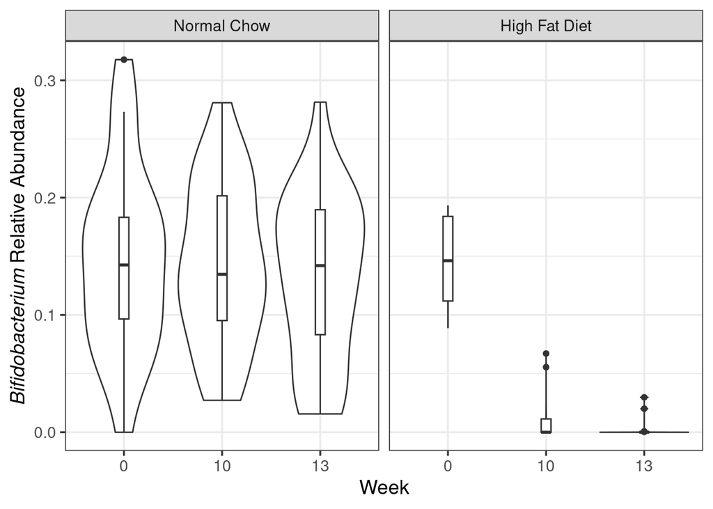

```r
# title = str_glue("Actinobacteria Relative Abundance, F; no surgery group")

f.ra.graph %>%
  filter(taxon == "Bifidobacterium" & Surgery == "None") %>%  # no surgery group!!!!
  ggplot(aes(x = Week_factor, y = RA)) +
  geom_violin() + geom_boxplot(width=0.1) +
  facet_wrap(vars(Diet))  +
  labs(y="*Bifidobacterium* Relative Abundance", x = "Week") +
  theme_bw(base_size = 14) +
  theme(axis.title.y = element_markdown())-> fig.Bifido.rel

fig.Bifido.rel
```

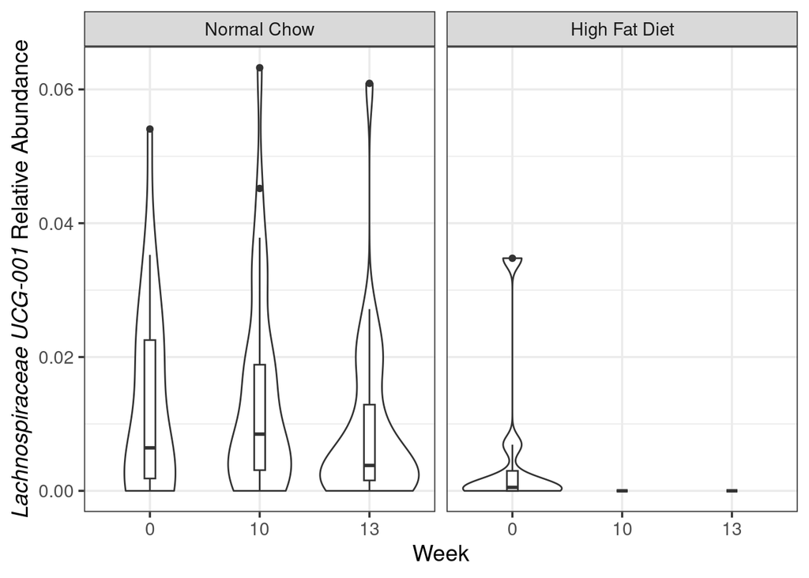

```r
f.ra.graph %>%
  filter(taxon == "Lachnospiraceae UCG-001" & Surgery == "None") %>%  # no surgery group!!!!
  ggplot(aes(x = Week_factor, y = RA)) +
  geom_violin() + geom_boxplot(width=0.1) +
  facet_wrap(vars(Diet))  +
  labs(y="*Lachnospiraceae UCG-001* Relative Abundance", x = "Week") +
  theme_bw(base_size = 14)+
  theme(axis.title.y = element_markdown()) -> fig.lachno.rel

fig.lachno.rel
```

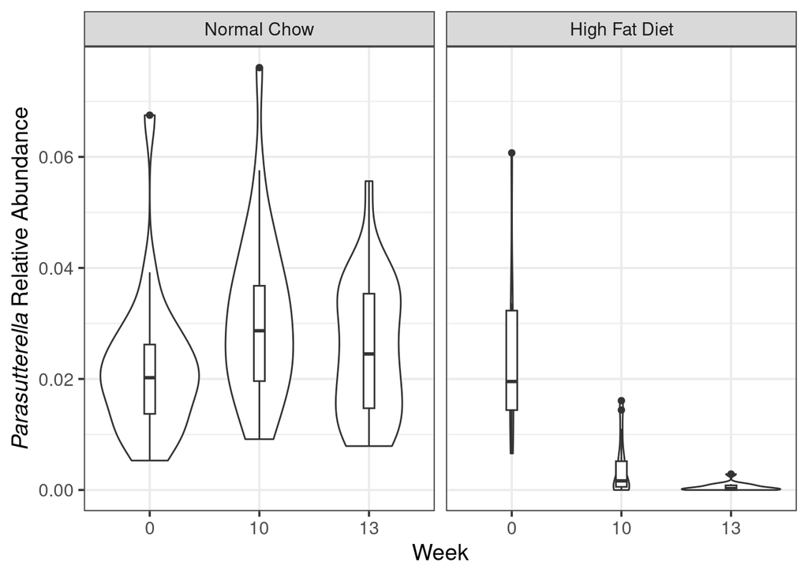

```r
f.ra.graph %>%
  filter(taxon == "Parasutterella" & Surgery == "None") %>%  # no surgery group!!!!
  ggplot(aes(x = Week_factor, y = RA)) +
  geom_violin() + geom_boxplot(width=0.1) +
  facet_wrap(vars(Diet))  +
  labs(y="*Parasutterella* Relative Abundance", x = "Week") +
  theme_bw(base_size = 14) +
  theme(axis.title.y = element_markdown()) -> fig.para.rel

fig.para.rel
```

```r
micro.corr.res %>%
  filter(taxon == "Lachnospiraceae UCG-001" | taxon == "Bifidobacterium" | taxon == "Parasutterella") %>%
  arrange(cor)
```

| Health_metric | taxon | cor | statistic | p | method | n | Week | Metric_Type | p.adj | p.adj.signif | p.adj.print | Taxonomic_Rank |
| --- | --- | --- | --- | --- | --- | --- | --- | --- | --- | --- | --- | --- |
| Leptin_pg_ml | Lachnospiraceae UCG-001 | -0.65 | 15069.214 | 1.05e-05 | Spearman | 38 | 13 | Serum proteins | 7.875000e-05 | **** | 7.9e-05 | Genus |
| Leptin_pg_ml | Parasutterella | -0.61 | 14700.660 | 5.04e-05 | Spearman | 38 | 13 | Serum proteins | 2.689615e-04 | *** | 2.7e-04 | Genus |
| Leptin_pg_ml | Bifidobacterium | -0.53 | 14003.091 | 5.83e-04 | Spearman | 38 | 13 | Serum proteins | 2.216199e-03 | ** | 2.2e-03 | Genus |
| MaxPeak | Parasutterella | -0.53 | 204660.917 | 5.81e-08 | Spearman | 93 | 0, 10, 13 (aggregated) | Glucose tolerance testing | 2.386500e-06 | **** | 2.4e-06 | Genus |
| AUC | Parasutterella | -0.50 | 200517.126 | 4.31e-07 | Spearman | 93 | 0, 10, 13 (aggregated) | Glucose tolerance testing | 6.294868e-06 | **** | 6.3e-06 | Genus |
| MaxPeak | Bifidobacterium | -0.48 | 198415.242 | 1.11e-06 | Spearman | 93 | 0, 10, 13 (aggregated) | Glucose tolerance testing | 1.283438e-05 | **** | 1.3e-05 | Genus |
| AUC | Bifidobacterium | -0.44 | 193415.137 | 8.75e-06 | Spearman | 93 | 0, 10, 13 (aggregated) | Glucose tolerance testing | 7.248134e-05 | **** | 7.2e-05 | Genus |
| Glucose_min_0 | Parasutterella | -0.44 | 193021.959 | 1.02e-05 | Spearman | 93 | 0, 10, 13 (aggregated) | Glucose tolerance testing | 7.754795e-05 | **** | 7.8e-05 | Genus |
| MaxPeak | Lachnospiraceae UCG-001 | -0.42 | 189722.417 | 3.47e-05 | Spearman | 93 | 0, 10, 13 (aggregated) | Glucose tolerance testing | 2.006094e-04 | *** | 2.0e-04 | Genus |
| Weight | Bifidobacterium | -0.39 | 1221743.482 | 9.17e-08 | Spearman | 174 | 0, 10, 13 (aggregated) | Weight | 2.400978e-06 | **** | 2.4e-06 | Genus |

[output cut: 12 more lines]

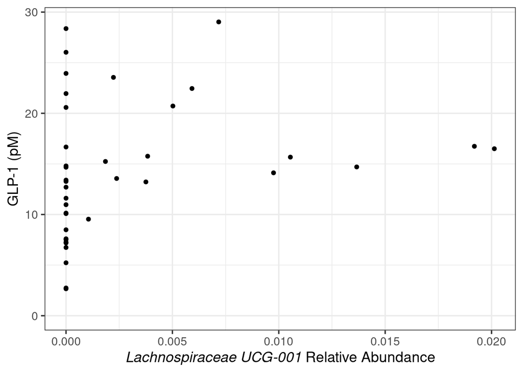

```r
protein.micro.corr %>%
    ggplot(aes(x = `Lachnospiraceae UCG-001`, y = GLP1_pM)) +
      geom_point() +
      labs(y= "GLP-1 (pM)",
           x= "*Lachnospiraceae UCG-001* Relative Abundance") +
      theme_bw(base_size = 14)+ expand_limits(y = 0) +
  theme(axis.title.x = element_markdown())-> fig.lachno.glp1
fig.lachno.glp1
```

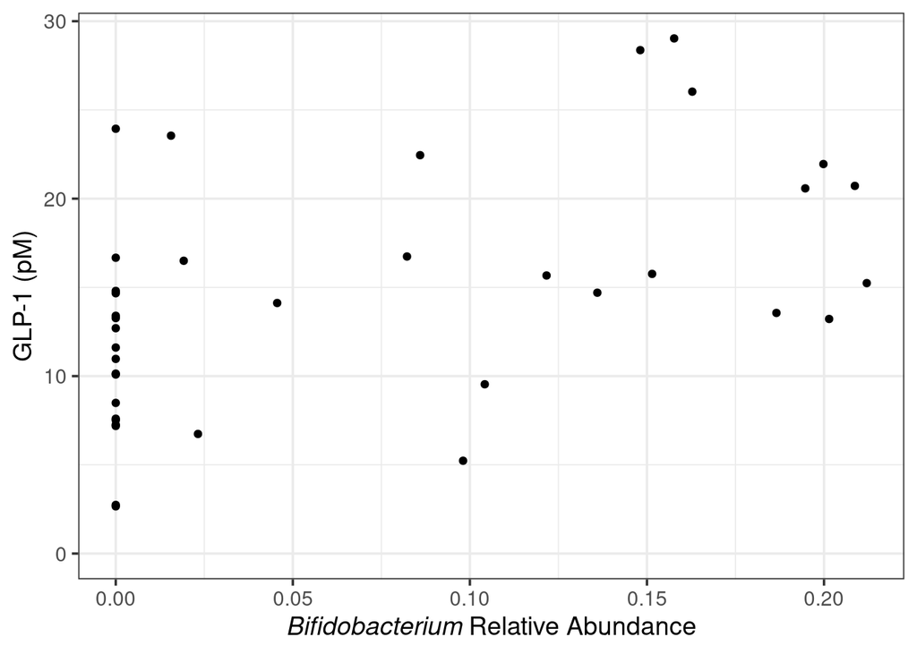

```r
protein.micro.corr %>%
    ggplot(aes(x = Bifidobacterium, y = GLP1_pM)) +
      geom_point() +
      labs(y= "GLP-1 (pM)",
           x= "*Bifidobacterium* Relative Abundance") +
      theme_bw(base_size = 14)+ expand_limits(y = 0)+
  theme(axis.title.x = element_markdown())  -> fig.bifido.glp1

fig.bifido.glp1
```

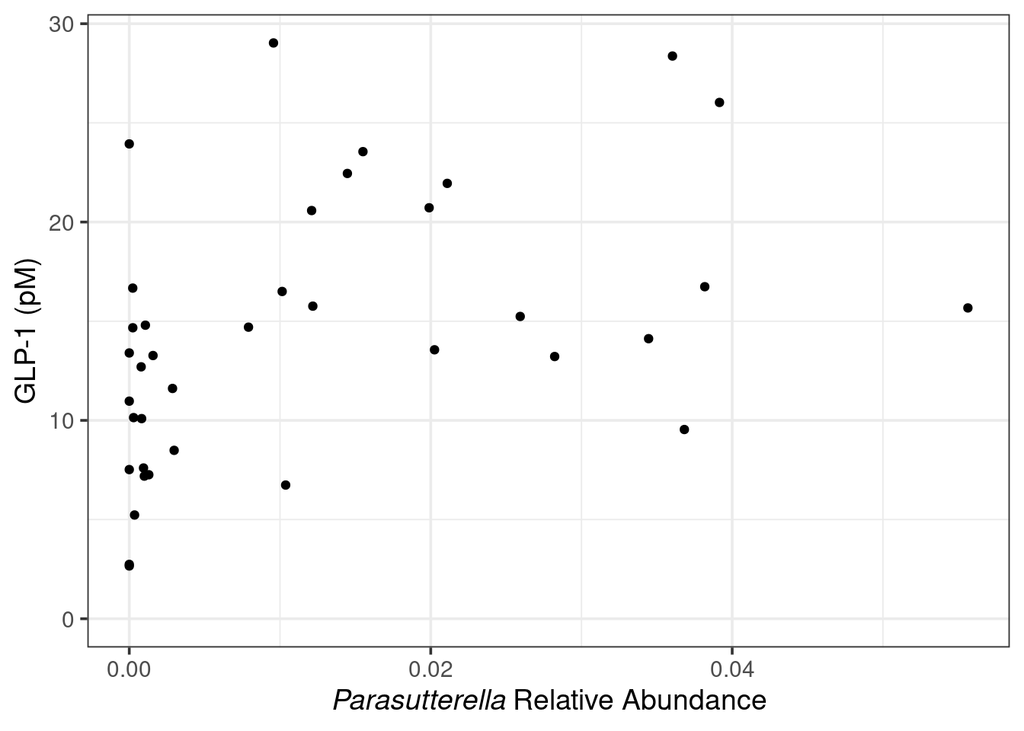

```r
protein.micro.corr %>%
    ggplot(aes(x = Parasutterella, y = GLP1_pM)) +
      geom_point() +
      labs(y= "GLP-1 (pM)",
           x= "*Parasutterella* Relative Abundance") +
      theme_bw(base_size = 14)+ expand_limits(y = 0) +
  theme(axis.title.x = element_markdown()) -> fig.para.glp1

fig.para.glp1
```

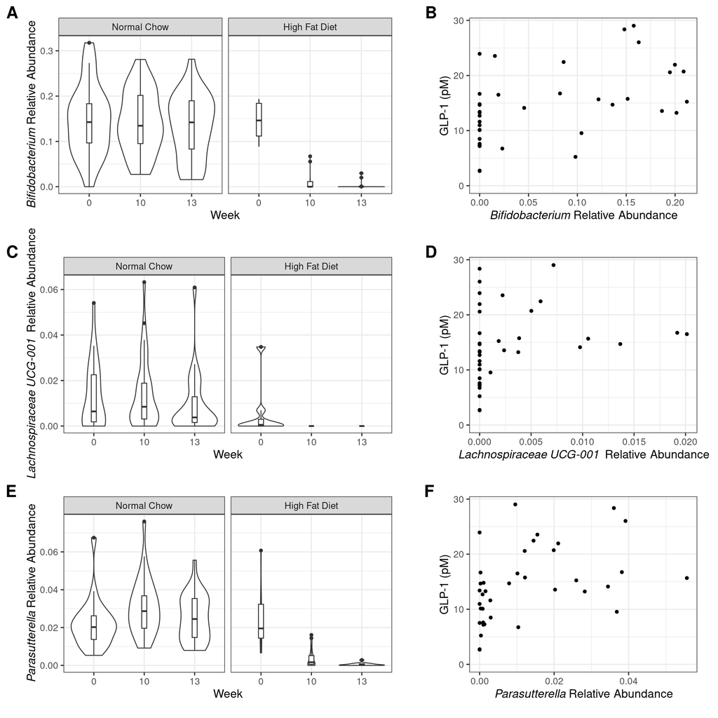

```r
plot_grid(
  fig.Bifido.rel, fig.bifido.glp1,
  fig.lachno.rel, fig.lachno.glp1,
  fig.para.rel, fig.para.glp1,
  labels = "AUTO", ncol = 2, label_size = 20, scale = 0.9,
  rel_widths = c(1.4, 1)
)
```

## Do graphs look prettier with arcsine transformation?

```r
protein.micro.corr %>% dplyr::select(-c(C_peptide_pg_ml, Ghrelin_pg_ml, Insulin_uIU_ml:PYY_pg_ml)) %>%
  pivot_longer(
    cols = c("Candidatus Stoquefichus":Verrucomicrobiota),
    names_to = "taxon",
    values_to = "RA"
  ) %>%
  dplyr::mutate(RA_arcsin = asin(sqrt(RA))) -> glp1.arcsine

head(glp1.arcsine)
```

| Label | Sample | GLP1_pM | taxon | RA | RA_arcsin |
| --- | --- | --- | --- | --- | --- |
| 265 | JI-723 | 10.14 | Candidatus Stoquefichus | 0.0000000000 | 0.00000000 |
| 265 | JI-723 | 10.14 | Romboutsia | 0.2030172414 | 0.46740859 |
| 265 | JI-723 | 10.14 | Streptococcus | 0.0050287356 | 0.07097315 |
| 265 | JI-723 | 10.14 | Lactococcus | 0.0658764368 | 0.25956904 |
| 265 | JI-723 | 10.14 | Parasutterella | 0.0002873563 | 0.01695240 |
| 265 | JI-723 | 10.14 | Tuzzerella | 0.0010057471 | 0.03171883 |

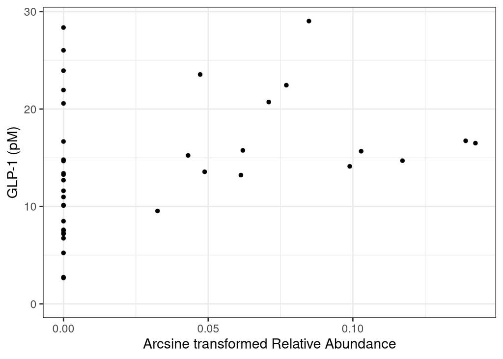

```r
glp1.arcsine %>%
  filter(taxon == "Lachnospiraceae UCG-001") %>%
    ggplot(aes(x = RA_arcsin, y = GLP1_pM)) +
      geom_point() +
      labs(y= "GLP-1 (pM)",
           x= "Arcsine transformed Relative Abundance") +
      theme_bw(base_size = 14)+ expand_limits(y = 0)
```

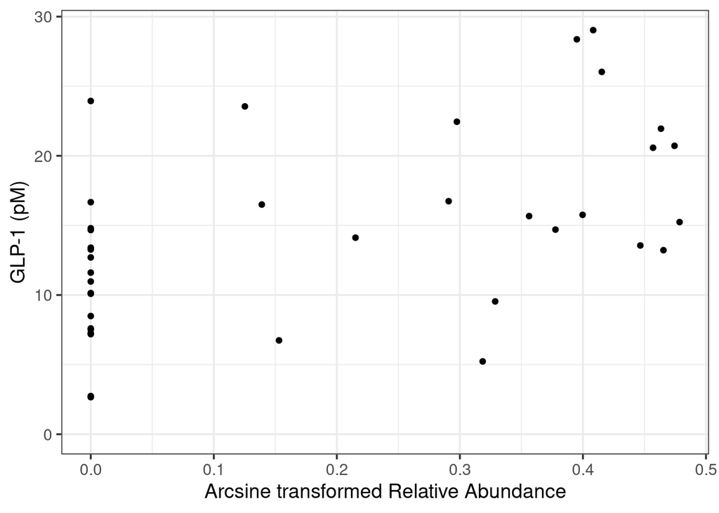

```r
glp1.arcsine %>%
  filter(taxon == "Bifidobacterium") %>%
    ggplot(aes(x = RA_arcsin, y = GLP1_pM)) +
      geom_point() +
      labs(y= "GLP-1 (pM)",
           x= "Arcsine transformed Relative Abundance") +
      theme_bw(base_size = 14)+ expand_limits(y = 0)
```

```r
glp1.arcsine %>% group_by(taxon) %>%
  shapiro_test(RA_arcsin) %>%
  add_significance()
```

| taxon | variable | statistic | p | p.signif |
| --- | --- | --- | --- | --- |
| Acetatifactor | RA_arcsin | 0.7513494 | 1.228013e-06 | **** |
| Actinobacteria | RA_arcsin | 0.7878698 | 5.975062e-06 | **** |
| Actinobacteriota | RA_arcsin | 0.8883137 | 1.212007e-03 | ** |
| Atopobiaceae | RA_arcsin | 0.8282795 | 4.157442e-05 | **** |
| Bifidobacteriaceae | RA_arcsin | 0.7812172 | 4.429932e-06 | **** |
| Bifidobacteriales | RA_arcsin | 0.7812172 | 4.429932e-06 | **** |
| Bifidobacterium | RA_arcsin | 0.7812172 | 4.429932e-06 | **** |
| Burkholderiales | RA_arcsin | 0.9037964 | 3.268031e-03 | ** |
| Candidatus Stoquefichus | RA_arcsin | 0.6642335 | 4.599060e-08 | **** |
| Coriobacteriaceae UCG-002 | RA_arcsin | 0.8282795 | 4.157442e-05 | **** |

[output cut: 27 more lines]

Still very much distinguishable from normal distribution.

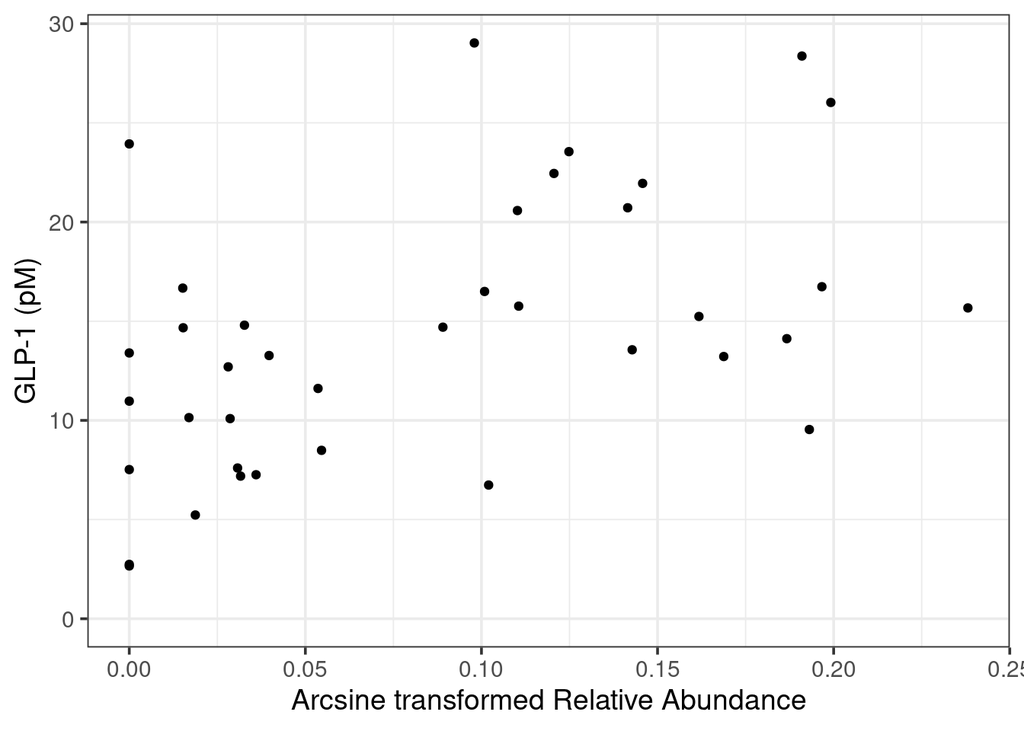

```r
glp1.arcsine %>%
  filter(taxon == "Parasutterella") %>%
    ggplot(aes(x = RA_arcsin, y = GLP1_pM)) +
      geom_point() +
      labs(y= "GLP-1 (pM)",
           x= "Arcsine transformed Relative Abundance") +
      theme_bw(base_size = 14)+ expand_limits(y = 0)
```